# Diploperennis with partner taxa in its union: dosage and fragmentation

chr10 GENOTYPE runs alone (1270808), D (+ parviglumis), E (+ mexicana), F (+ both); 2026-10-16

Author

Fausto Rodríguez-Zapata

Published

October 16, 2026

## Why

User, 2026-10-16: “plan the same approach for diplo as we did for huehue: make the genotyping using information from parviglumis and mexicana; there is a chance that the fragmentation improves; judging by the FST it should work”; then, for this notebook, the effect of partner taxa in the union on dosage and fragmentation. Run plan: `docs/runs/genotype_diploperennis_partners_chr10.md`. Runs shown: alone, D, E, F.

Inputs (not in git): small tables in `diplo_partners/`, made by `agent/diplo_chr10/collect.sh` and `agent/nb08/collect.sh` (logs there) and the measurement jobs (`agent/diplo_chr10/measure_diplo_*.log`); master copy in `/rsstu/users/r/rrellan/BZea/ZEAL/genotype/notebook_inputs/diplo_partners/`; copy it next to this notebook to re-render.

## 1. Union and markers

RTIGER markers per donor (union sites called ALT for it). Union sites: alone 227,086; + parviglumis 557,179; + mexicana 510,623; + both 727,756.

| donor | alone | + parviglumis | + mexicana | + both |
| --- | --- | --- | --- | --- |
| Zd.0010_P2 | 90,830 | 109,635 | 101,605 | 111,236 |
| Zd.0010_P3 | 155,335 | 174,182 | 166,103 | 177,599 |
| Zd.0020_P2 | 87,308 | 92,549 | 88,181 | 93,154 |
| Zd.0020_P3 | 33,229 | 30,981 | 29,896 | 30,506 |
| Zd.0030_P2 | 77,996 | 72,884 | 69,540 | 71,654 |
| Zd.0040_P1 | 76,665 | 106,101 | 100,558 | 112,708 |

The union grows 2-2.5-fold with a partner taxon; each donor’s markers far less, and two donors lose a few: a donor still takes only the union sites its own BC1 reads support.

## 2. Dosage

### ALT % per segment state

Medians over the donor’s BC2S3 samples of the ALT % of reads in REF / HET / ALT segments.

| donor | union | samples | REF | HET | ALT | passing the dosage check |
| --- | --- | --- | --- | --- | --- | --- |
| Zd.0010_P2 | alone | 48 | 2.0 | 42.6 | 79.9 | 36 |
| Zd.0010_P2 | + parviglumis | 48 | 1.8 | 39.4 | 76.0 | 36 |
| Zd.0010_P2 | + mexicana | 48 | 1.8 | 38.5 | 75.7 | 35 |
| Zd.0010_P2 | + both | 48 | 1.8 | 39.4 | 74.7 | 35 |
| Zd.0010_P3 | alone | 38 | 1.2 | 25.1 | 82.7 | 22 |
| Zd.0010_P3 | + parviglumis | 38 | 1.1 | 24.2 | 83.2 | 22 |
| Zd.0010_P3 | + mexicana | 38 | 1.1 | 26.0 | 83.4 | 23 |
| Zd.0010_P3 | + both | 38 | 1.1 | 24.1 | 83.2 | 22 |
| Zd.0020_P2 | alone | 26 | 1.4 | 54.6 | 88.3 | 22 |
| Zd.0020_P2 | + parviglumis | 26 | 1.5 | 52.8 | 88.7 | 22 |
| Zd.0020_P2 | + mexicana | 26 | 1.5 | 54.0 | 88.8 | 22 |
| Zd.0020_P2 | + both | 26 | 1.5 | 52.2 | 88.7 | 22 |
| Zd.0020_P3 | alone | 40 | 2.9 | 32.7 | 73.5 | 13 |
| Zd.0020_P3 | + parviglumis | 40 | 3.0 | 31.8 | 72.6 | 12 |
| Zd.0020_P3 | + mexicana | 40 | 2.9 | 32.8 | 72.3 | 11 |
| Zd.0020_P3 | + both | 40 | 2.8 | 32.1 | 70.1 | 11 |
| Zd.0030_P2 | alone | 63 | 1.6 | 40.0 | 89.6 | 50 |
| Zd.0030_P2 | + parviglumis | 63 | 1.7 | 40.3 | 88.6 | 46 |
| Zd.0030_P2 | + mexicana | 63 | 1.7 | 40.4 | 86.8 | 46 |
| Zd.0030_P2 | + both | 63 | 1.7 | 40.6 | 88.7 | 46 |
| Zd.0040_P1 | alone | 38 | 1.4 | 40.1 | 84.6 | 30 |
| Zd.0040_P1 | + parviglumis | 38 | 1.2 | 37.6 | 77.8 | 29 |
| Zd.0040_P1 | + mexicana | 38 | 1.2 | 36.5 | 74.7 | 25 |
| Zd.0040_P1 | + both | 38 | 1.1 | 35.6 | 73.0 | 24 |

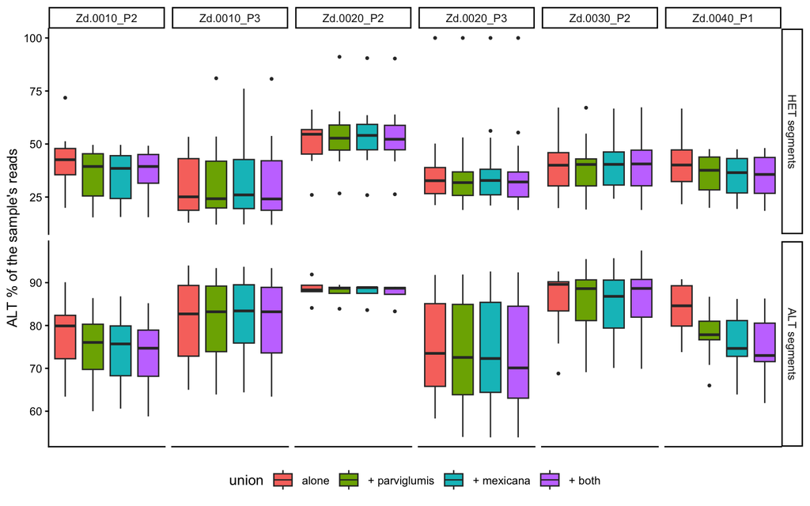

### Own and gap markers

ALT % of the samples’ reads per segment state, at the donor’s own and gap markers.

| donor | src | alone_REF | alone_HET | alone_ALT | + parviglumis_REF | + parviglumis_HET | + parviglumis_ALT | + mexicana_REF | + mexicana_HET | + mexicana_ALT | + both_REF | + both_HET | + both_ALT |
| --- | --- | --- | --- | --- | --- | --- | --- | --- | --- | --- | --- | --- | --- |
| Zd.0010_P2 | gap | 1.5 | 37.9 | 74.6 | 1.3 | 33.8 | 67.2 | 1.3 | 34.0 | 67.9 | 1.3 | 33.2 | 66.0 |
| Zd.0010_P2 | own | 2.5 | 42.4 | 79.0 | 2.6 | 43.8 | 79.7 | 2.6 | 43.2 | 79.6 | 2.6 | 43.8 | 79.8 |
| Zd.0010_P3 | gap | 1.1 | 22.2 | 75.7 | 0.9 | 21.5 | 75.3 | 0.9 | 21.5 | 75.6 | 0.8 | 21.3 | 75.1 |
| Zd.0010_P3 | own | 1.6 | 30.1 | 88.3 | 1.7 | 30.5 | 88.7 | 1.7 | 30.7 | 88.9 | 1.7 | 30.7 | 88.8 |
| Zd.0020_P2 | gap | 0.7 | 46.8 | 88.8 | 0.7 | 48.8 | 88.2 | 0.7 | 48.9 | 88.1 | 0.7 | 48.3 | 87.9 |
| Zd.0020_P2 | own | 5.5 | 55.5 | 87.3 | 5.9 | 57.2 | 87.5 | 5.9 | 57.4 | 87.9 | 6.0 | 57.3 | 87.9 |
| Zd.0020_P3 | gap | 1.7 | 32.0 | 76.6 | 1.8 | 30.4 | 76.4 | 1.7 | 30.3 | 77.1 | 1.7 | 29.3 | 75.0 |
| Zd.0020_P3 | own | 4.1 | 33.4 | 71.2 | 4.3 | 33.7 | 70.6 | 4.2 | 33.5 | 71.1 | 4.2 | 32.9 | 69.2 |
| Zd.0030_P2 | gap | 1.2 | 37.7 | 88.7 | 1.3 | 36.7 | 87.2 | 1.3 | 36.5 | 87.2 | 1.3 | 36.8 | 87.3 |
| Zd.0030_P2 | own | 2.4 | 38.8 | 86.4 | 2.7 | 39.2 | 86.8 | 2.6 | 39.3 | 86.8 | 2.7 | 39.6 | 87.2 |
| Zd.0040_P1 | gap | 1.5 | 33.6 | 71.5 | 1.1 | 28.5 | 71.5 | 1.0 | 27.6 | 70.6 | 1.0 | 26.5 | 69.8 |
| Zd.0040_P1 | own | 2.0 | 43.3 | 91.4 | 2.0 | 43.9 | 91.2 | 2.0 | 43.7 | 91.4 | 2.0 | 43.6 | 91.3 |

### Class shares and donor allele frequency

Shares of chr10 bp called HET / ALT and donor allele frequency (HET 0.5, ALT 1); BC2S2: 6.25 / 9.4 / 12.5 %.

| donor | HET_alone | HET_+ parviglumis | HET_+ mexicana | HET_+ both | ALT_alone | ALT_+ parviglumis | ALT_+ mexicana | ALT_+ both | allele_alone | allele_+ parviglumis | allele_+ mexicana | allele_+ both |
| --- | --- | --- | --- | --- | --- | --- | --- | --- | --- | --- | --- | --- |
| Zd.0010_P2 | 4.5 | 4.6 | 4.5 | 4.5 | 5.4 | 5.2 | 5.3 | 5.3 | 7.7 | 7.5 | 7.6 | 7.6 |
| Zd.0010_P3 | 8.5 | 8.7 | 8.6 | 8.6 | 7.6 | 7.6 | 7.5 | 7.6 | 11.8 | 11.9 | 11.9 | 11.9 |
| Zd.0020_P2 | 0.8 | 0.8 | 0.8 | 0.8 | 3.4 | 3.4 | 3.4 | 3.4 | 3.8 | 3.8 | 3.8 | 3.8 |
| Zd.0020_P3 | 16.9 | 18.5 | 18.9 | 19.2 | 3.7 | 3.9 | 3.8 | 4.1 | 12.2 | 13.1 | 13.2 | 13.7 |
| Zd.0030_P2 | 7.7 | 7.7 | 7.7 | 7.8 | 4.1 | 4.2 | 4.2 | 4.2 | 8.0 | 8.1 | 8.1 | 8.1 |
| Zd.0040_P1 | 6.7 | 6.3 | 6.4 | 6.4 | 4.2 | 4.3 | 4.3 | 4.4 | 7.6 | 7.5 | 7.5 | 7.6 |

## 3. Fragmentation

Donor segments per sample.

| donor | union | samples | median segments | mean | p90 | max | samples > 4 segments | REF % ALT > 3 |
| --- | --- | --- | --- | --- | --- | --- | --- | --- |
| Zd.0010_P2 | alone | 48 | 1 | 1.0 | 2.0 | 7 | 2 | 3 |
| Zd.0010_P2 | + parviglumis | 48 | 1 | 0.9 | 2.0 | 6 | 2 | 4 |
| Zd.0010_P2 | + mexicana | 48 | 1 | 0.9 | 2.0 | 6 | 2 | 3 |
| Zd.0010_P2 | + both | 48 | 1 | 0.9 | 2.0 | 6 | 2 | 3 |
| Zd.0010_P3 | alone | 38 | 1 | 1.1 | 2.0 | 10 | 2 | 2 |
| Zd.0010_P3 | + parviglumis | 38 | 1 | 1.1 | 2.0 | 8 | 2 | 2 |
| Zd.0010_P3 | + mexicana | 38 | 1 | 1.1 | 2.0 | 8 | 2 | 2 |
| Zd.0010_P3 | + both | 38 | 1 | 1.1 | 2.0 | 8 | 2 | 2 |
| Zd.0020_P2 | alone | 26 | 0 | 0.3 | 1.0 | 1 | 0 | 0 |
| Zd.0020_P2 | + parviglumis | 26 | 0 | 0.3 | 1.0 | 1 | 0 | 0 |
| Zd.0020_P2 | + mexicana | 26 | 0 | 0.3 | 1.0 | 1 | 0 | 0 |
| Zd.0020_P2 | + both | 26 | 0 | 0.3 | 1.0 | 1 | 0 | 0 |
| Zd.0020_P3 | alone | 40 | 2 | 3.0 | 7.0 | 14 | 10 | 19 |
| Zd.0020_P3 | + parviglumis | 40 | 3 | 3.3 | 6.1 | 12 | 13 | 17 |
| Zd.0020_P3 | + mexicana | 40 | 3 | 3.4 | 7.0 | 11 | 14 | 17 |
| Zd.0020_P3 | + both | 40 | 3 | 3.3 | 6.1 | 9 | 14 | 17 |
| Zd.0030_P2 | alone | 63 | 0 | 0.7 | 2.0 | 4 | 0 | 9 |
| Zd.0030_P2 | + parviglumis | 63 | 0 | 0.7 | 2.0 | 4 | 0 | 14 |
| Zd.0030_P2 | + mexicana | 63 | 1 | 0.9 | 2.8 | 5 | 1 | 11 |
| Zd.0030_P2 | + both | 63 | 0 | 0.8 | 2.0 | 4 | 0 | 14 |
| Zd.0040_P1 | alone | 38 | 1 | 1.2 | 2.0 | 19 | 1 | 4 |
| Zd.0040_P1 | + parviglumis | 38 | 1 | 1.0 | 1.3 | 15 | 1 | 3 |
| Zd.0040_P1 | + mexicana | 38 | 1 | 1.1 | 1.3 | 18 | 1 | 3 |
| Zd.0040_P1 | + both | 38 | 1 | 1.0 | 2.0 | 16 | 1 | 3 |

SNP50K HET segments of at least 1 Mb, and how many pieces (segments of any state) each run calls over them in the same sample (the fragmentation measure of the 2026-10-15 diagnosis):

Share (%) of SNP50K HET segments >= 1 Mb kept whole (1 piece) and split into >= 3 pieces.

| donor | whole_alone | whole_+ parviglumis | whole_+ mexicana | whole_+ both | split3_alone | split3_+ parviglumis | split3_+ mexicana | split3_+ both |
| --- | --- | --- | --- | --- | --- | --- | --- | --- |
| Zd.0010_P2 | 40.0 | 33.3 | 33.3 | 33.3 | 33.3 | 26.7 | 33.3 | 26.7 |
| Zd.0010_P3 | 41.2 | 41.2 | 41.2 | 41.2 | 41.2 | 41.2 | 41.2 | 47.1 |
| Zd.0020_P2 | 62.5 | 62.5 | 62.5 | 62.5 | 37.5 | 37.5 | 37.5 | 37.5 |
| Zd.0020_P3 | 34.3 | 37.1 | 40.0 | 42.9 | 48.6 | 48.6 | 48.6 | 45.7 |
| Zd.0030_P2 | 54.8 | 57.1 | 54.8 | 57.1 | 21.4 | 16.7 | 21.4 | 16.7 |
| Zd.0040_P1 | 36.8 | 42.1 | 36.8 | 47.4 | 36.8 | 26.3 | 31.6 | 21.1 |